# 04. Regularization

Carmen Coronas

October/November 2024

## Cross Validation Example

```r
SC <- read.csv("../Data/semiconductor.csv")
full <- glm(FAIL ~ ., data=SC, family=binomial)
1 - full$deviance/full$null.deviance
```

```
## [1] 0.5621432
```

R2 = 56% of variance explained (R2 IS).

Step 1- K-fold functions

```r
## Out of sample prediction experiment
## pred must be probabilities (0<pred<1) for binomial
deviance <- function(y, pred, family=c("gaussian","binomial")){
    family <- match.arg(family)
    if(family=="gaussian"){
        return( sum( (y-pred)^2 ) )
    }else{
        if(is.factor(y)) y <- as.numeric(y)>1
        return( -2*sum( y*log(pred) + (1-y)*log(1-pred) ) )
    }
}
## get null deviance too, and return R2
R2 <- function(y, pred, family=c("gaussian","binomial")){
    fam <- match.arg(family)
    if(fam=="binomial"){
        if(is.factor(y)){ y <- as.numeric(y)>1 }
    }
    dev <- deviance(y, pred, family=fam)
    dev0 <- deviance(y, mean(y), family=fam) # Instead of using mean, we use median.
    return(1-dev/dev0)
}
```

Step 2- K-Fold Partition/Experiment

```r
# setup the experiment
n <- nrow(SC) # the number of observations
K <- 10 # the number of `folds'
# create a vector of fold memberships (random order)
foldid <- rep(1:K,each=ceiling(n/K))[sample(1:n)]
# create an empty dataframe of results
Out <- data.frame(full=rep(NA,K))
# use a for loop to run the experiment
for(k in 1:K){
    train <- which(foldid!=k) # train on all but fold `k'
    ## fit regression on full sample
    rfull <- glm(FAIL~., data=SC, subset=train, family=binomial)
    ## get prediction: type=response so we have probabilities
    predfull <- predict(rfull, newdata=SC[-train,], type="response")
    ## calculate and log R2
    Out$full[k] <- R2(y=SC$FAIL[-train], pred=predfull, family="binomial")
    ## print progress
    cat(k, " ")
}
```

```
## 1
```

```
## 2
```

```
## 3
```

```
## 4
```

```
## 5
```

```
## 6
```

```
## 7
```

```
## 8
```

```
## 9
```

```
## 10
```

Step 3- K-Fold Plots

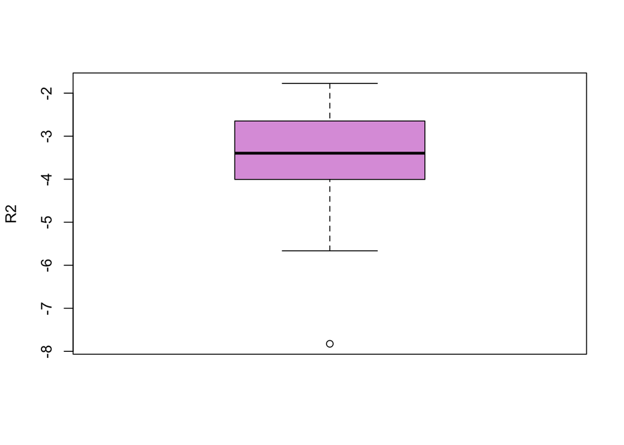

```r
boxplot(Out, col="plum", ylab="R2")
```

```r
## what are the average Out R2?
colMeans(Out)
```

```
##     full
## -3.75405
```

Negative OOS R2. Overfitting: excessively adjusted to IS data, performs poorly in OOS data.

### Step 1- K-fold functions

```r
## Out of sample prediction experiment
## first, define the deviance and R2 functions
## pred must be probabilities (0<pred<1) for binomial
deviance_2 <- function(y, pred, family=c("gaussian","binomial")){
    family_2 <- match.arg(family)
    if(family=="gaussian"){
        return( sum( (y-pred)^2 ) )
    }else{
        if(is.factor(y)) y <- as.numeric(y)>1
        return( -2*sum( y*log(pred) + (1-y)*log(1-pred) ) )
    }
}
## get null devaince too, and return R2
R2_2 <- function(y, pred, family=c("gaussian","binomial")){
    fam2 <- match.arg(family)
    if(fam=="binomial"){
        if(is.factor(y)){ y <- as.numeric(y)>1 }
    }
    dev_2 <- deviance(y, pred, family=fam)
    dev0_2 <- deviance(y, mean(y), family=fam)
    return(1-dev/dev0)
}
```

### Step 2- K-Fold Partition/Experiment

```r
# setup the experiment
n_2 <- nrow(SC) # the number of observations
K_2 <- 5 # the number of folds: 5 NOW!!
# create a vector of fold memberships (random order)
foldid_2 <- rep(1:K,each=ceiling(n/K))[sample(1:n)]
# create an empty dataframe of results
Out_2 <- data.frame(full=rep(NA,K))
# use a for loop to run the experiment
for(k in 1:K){
    train_2 <- which(foldid!=k) # train on all but fold `k'
    ## fit regression on full sample
    rfull_2 <- glm(FAIL~., data=SC, subset=train_2, family=binomial)
    ## get prediction: type=response so we have probabilities
    predfull_2 <- predict(rfull, newdata=SC[-train_2,], type="response")
    ## calculate and log R2
    Out_2$full[k] <- R2(y=SC$FAIL[-train_2], pred=predfull, family="binomial")
    ## print progress
    cat(k, " ")
}
```

```
## 1
```

```
## 2
```

```
## 3
```

```
## 4
```

```
## 5
```

```
## 6
```

```
## 7
```

```
## 8
```

```
## 9
```

```
## 10
```

### Step 3- K-Fold Plots

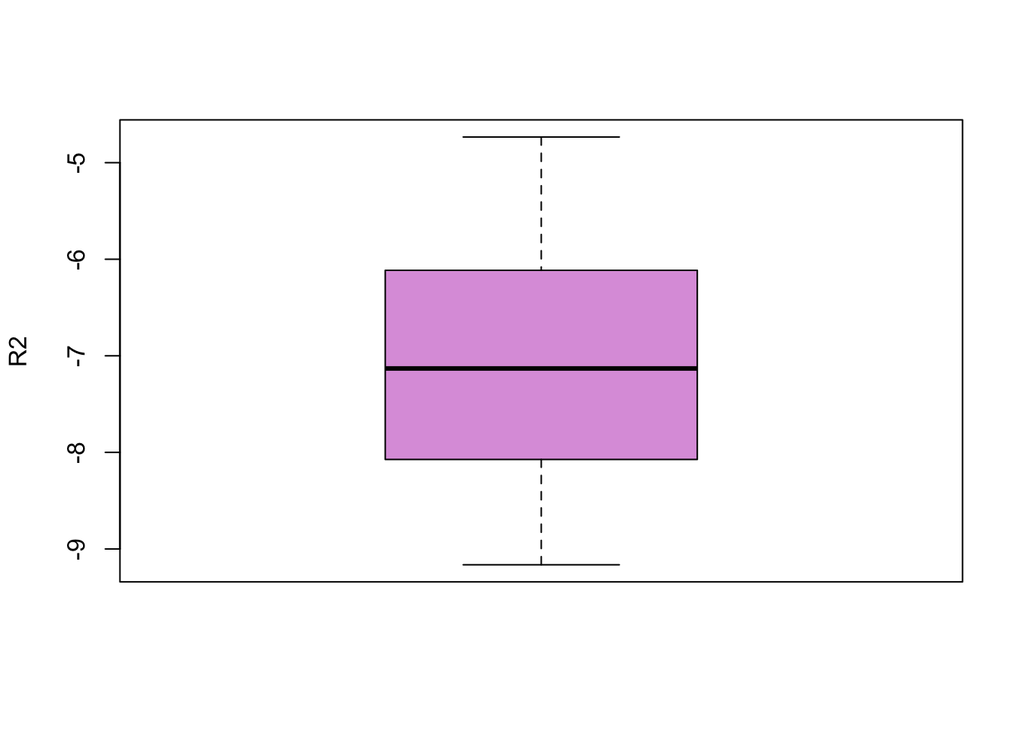

```r
boxplot(Out_2, col="plum", ylab="R2")
```

### R^2

```r
## what are the average Out R2?
colMeans(Out_2)
```

```
##      full
## -7.178717
```

## Regularization paths

### Forward Stepwise Regression

```r
null <- glm(FAIL~1, data=SC)
fwd <- step(null, scope=formula(full), dir="forward")
```

```
## Start:  AIC=115.03
## FAIL ~ 1
##
##          Df Deviance     AIC
## + SIG2    1   91.699  92.588
## + SIG189  1   92.132  99.534
## + SIG13   1   92.327 102.664
## + SIG166  1   92.406 103.923
## + SIG61   1   92.463 104.832
## + SIG173  1   92.588 106.832
## + SIG50   1   92.619 107.323
## + SIG167  1   92.743 109.302
## + SIG24   1   92.793 110.103
## + SIG18   1   92.813 110.419
## + SIG154  1   92.830 110.685
## + SIG178  1   92.893 111.690
## + SIG57   1   92.897 111.761
## + SIG136  1   92.918 112.094
## + SIG7    1   92.934 112.344
## + SIG117  1   92.934 112.345
## + SIG147  1   92.937 112.387
## + SIG104  1   92.948 112.564
## + SIG153  1   92.971 112.926
## + SIG193  1   92.973 112.959
## + SIG97   1   92.977 113.029
## + SIG99   1   92.978 113.042
## + SIG42   1   92.983 113.125
## + SIG175  1   92.994 113.293
## + SIG142  1   92.997 113.347
## + SIG133  1   92.998 113.360
## + SIG155  1   93.016 113.644
## + SIG111  1   93.022 113.735
## + SIG169  1   93.023 113.762
## + SIG134  1   93.030 113.867
## + SIG16   1   93.036 113.968
## + SIG27   1   93.037 113.971
## + SIG80   1   93.039 114.004
## + SIG110  1   93.042 114.058
## + SIG66   1   93.043 114.067
## + SIG151  1   93.054 114.246
```

[output cut: 12108 more lines]

```
## + SIG36   1   74.554 -77.147
## + SIG55   1   74.554 -77.147
## + SIG183  1   74.554 -77.140
## + SIG6    1   74.554 -77.138
## + SIG143  1   74.554 -77.138
## + SIG120  1   74.554 -77.134
## + SIG157  1   74.555 -77.123
## + SIG26   1   74.555 -77.122
## + SIG112  1   74.555 -77.122
## + SIG19   1   74.555 -77.122
## + SIG121  1   74.555 -77.122
## + SIG87   1   74.555 -77.122
## + SIG70   1   74.555 -77.121
## + SIG158  1   74.555 -77.121
## + SIG123  1   74.555 -77.121
```

## Graph: sparsity decreases with number of covariates (p)

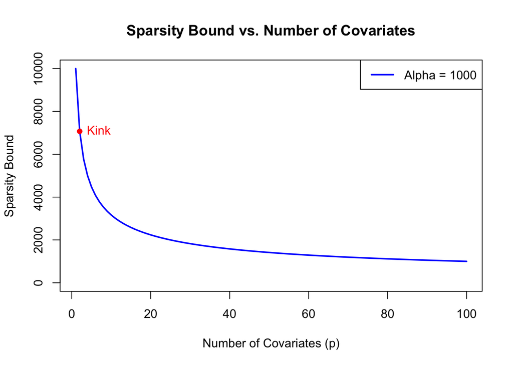

```r
calculate_sparsity_bound <- function(p, N, alpha) { return(alpha * sqrt(N) / sqrt(p))}#Define a function to calculate the sparsity bound

N <- 100#Set parameters

alpha <- 1000#Set parameters

p_values <- seq(1, 100, by = 1) ##Set parameters. Adjust the range of p as needed

bound_values <- sapply(p_values, calculate_sparsity_bound, N = N, alpha = alpha)# Calculate sparsity bounds for each p

kink_point <- which.min(diff(bound_values)) + 1# Identify the kink point

plot(p_values, bound_values, type = "l", col = "blue", lwd = 2, xlab = "Number of Covariates (p)", ylab = "Sparsity Bound", main = "Sparsity Bound vs. Number of Covariates", ylim = c(0, max(bound_values)))# Plot the sparsity bounds

points(p_values[kink_point], bound_values[kink_point], col = "red", pch = 16)# Highlight the kink point

text(p_values[kink_point], bound_values[kink_point], "Kink", pos = 4, col = "red")# Highlight the kink point

legend("topright", legend = sprintf("Alpha = %d", alpha), col = "blue", lwd = 2)# Add a legend
```

## Lasso regularization path

```r
library(gamlr)
```

```r
## Browsing History.
## web has 3 colums: [machine] id, site [id], [# of] visits
web <- read.csv("../Data/browser-domains.csv")
## Read in actual website names and relabel site factor
sitenames <- scan("../Data/browser-sites.txt", what="character")
web$site <- factor(web$site, levels=1:length(sitenames), labels=sitenames)
## also factor machine id
web$id <- factor(web$id, levels=1:length(unique(web$id)))
## get total visits per-machine and % of time on each site
## tapply(a,b,c) does c(a) for every level of factor b.
machinetotals <- as.vector(tapply(web$visits,web$id,sum))
visitpercent <- 100*web$visits/machinetotals[web$id]
## use this info in a sparse matrix
## this is something you'll be doing a lot; familiarize yourself.
xweb <- sparseMatrix(
    i=as.numeric(web$id), j=as.numeric(web$site), x=visitpercent,
    dims=c(nlevels(web$id),nlevels(web$site)),
    dimnames=list(id=levels(web$id), site=levels(web$site)))
# what sites did household 1 visit?
#head(xweb[1, xweb[1,]!=0])
## now read in the spending data
yspend <- read.csv("../Data/browser-totalspend.csv", row.names=1)  # us 1st column as row names
yspend <- as.matrix(yspend) ## good practice to move from dataframe to matrix
```

```r
spender <- gamlr(xweb, log(yspend), verb=TRUE); spender
```

```
## *** n=10000 observations and p=1000 covariates ***
## segment 1: lambda = 0.2325, dev = 2.783e+04, npass = 0
## segment 2: lambda = 0.2219, dev = 2.778e+04, npass = 3
## segment 3: lambda = 0.2118, dev = 2.774e+04, npass = 3
## segment 4: lambda = 0.2022, dev = 2.77e+04, npass = 3
## segment 5: lambda = 0.193, dev = 2.766e+04, npass = 3
## segment 6: lambda = 0.1842, dev = 2.76e+04, npass = 3
## segment 7: lambda = 0.1759, dev = 2.753e+04, npass = 4
## segment 8: lambda = 0.1679, dev = 2.744e+04, npass = 5
## segment 9: lambda = 0.1602, dev = 2.733e+04, npass = 5
## segment 10: lambda = 0.153, dev = 2.72e+04, npass = 5
## segment 11: lambda = 0.146, dev = 2.708e+04, npass = 5
## segment 12: lambda = 0.1394, dev = 2.697e+04, npass = 5
## segment 13: lambda = 0.133, dev = 2.687e+04, npass = 5
## segment 14: lambda = 0.127, dev = 2.676e+04, npass = 5
## segment 15: lambda = 0.1212, dev = 2.663e+04, npass = 5
## segment 16: lambda = 0.1157, dev = 2.65e+04, npass = 5
## segment 17: lambda = 0.1104, dev = 2.639e+04, npass = 5
## segment 18: lambda = 0.1054, dev = 2.628e+04, npass = 5
## segment 19: lambda = 0.1006, dev = 2.616e+04, npass = 5
## segment 20: lambda = 0.09606, dev = 2.605e+04, npass = 5
## segment 21: lambda = 0.09169, dev = 2.595e+04, npass = 5
## segment 22: lambda = 0.08753, dev = 2.584e+04, npass = 5
## segment 23: lambda = 0.08355, dev = 2.574e+04, npass = 4
## segment 24: lambda = 0.07975, dev = 2.564e+04, npass = 4
## segment 25: lambda = 0.07613, dev = 2.553e+04, npass = 4
## segment 26: lambda = 0.07267, dev = 2.543e+04, npass = 4
## segment 27: lambda = 0.06936, dev = 2.532e+04, npass = 4
## segment 28: lambda = 0.06621, dev = 2.522e+04, npass = 4
## segment 29: lambda = 0.0632, dev = 2.511e+04, npass = 4
## segment 30: lambda = 0.06033, dev = 2.501e+04, npass = 4
## segment 31: lambda = 0.05759, dev = 2.491e+04, npass = 4
## segment 32: lambda = 0.05497, dev = 2.481e+04, npass = 4
## segment 33: lambda = 0.05247, dev = 2.47e+04, npass = 4
## segment 34: lambda = 0.05009, dev = 2.46e+04, npass = 4
## segment 35: lambda = 0.04781, dev = 2.449e+04, npass = 5
## segment 36: lambda = 0.04564, dev = 2.438e+04, npass = 5
## segment 37: lambda = 0.04356, dev = 2.427e+04, npass = 6
## segment 38: lambda = 0.04158, dev = 2.416e+04, npass = 6
## segment 39: lambda = 0.03969, dev = 2.405e+04, npass = 6
```

[output cut: 46 more lines]

```
## segment 86: lambda = 0.004459, dev = 2.109e+04, npass = 8
## segment 87: lambda = 0.004256, dev = 2.107e+04, npass = 8
## segment 88: lambda = 0.004063, dev = 2.105e+04, npass = 8
## segment 89: lambda = 0.003878, dev = 2.103e+04, npass = 7
## segment 90: lambda = 0.003702, dev = 2.102e+04, npass = 7
## segment 91: lambda = 0.003533, dev = 2.1e+04, npass = 7
## segment 92: lambda = 0.003373, dev = 2.098e+04, npass = 7
## segment 93: lambda = 0.00322, dev = 2.097e+04, npass = 6
## segment 94: lambda = 0.003073, dev = 2.095e+04, npass = 6
## segment 95: lambda = 0.002934, dev = 2.094e+04, npass = 6
## segment 96: lambda = 0.0028, dev = 2.093e+04, npass = 6
## segment 97: lambda = 0.002673, dev = 2.091e+04, npass = 6
## segment 98: lambda = 0.002551, dev = 2.09e+04, npass = 5
## segment 99: lambda = 0.002435, dev = 2.089e+04, npass = 5
## segment 100: lambda = 0.002325, dev = 2.088e+04, npass = 5
```

```
##
## gaussian gamlr with 1000 inputs and 100 segments.
```

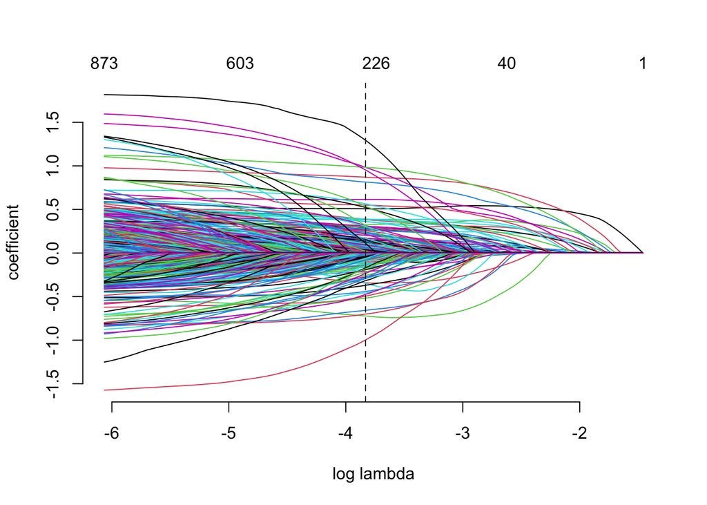

```r
plot(spender) ## path plot
```

```r
library (glmnet)
```

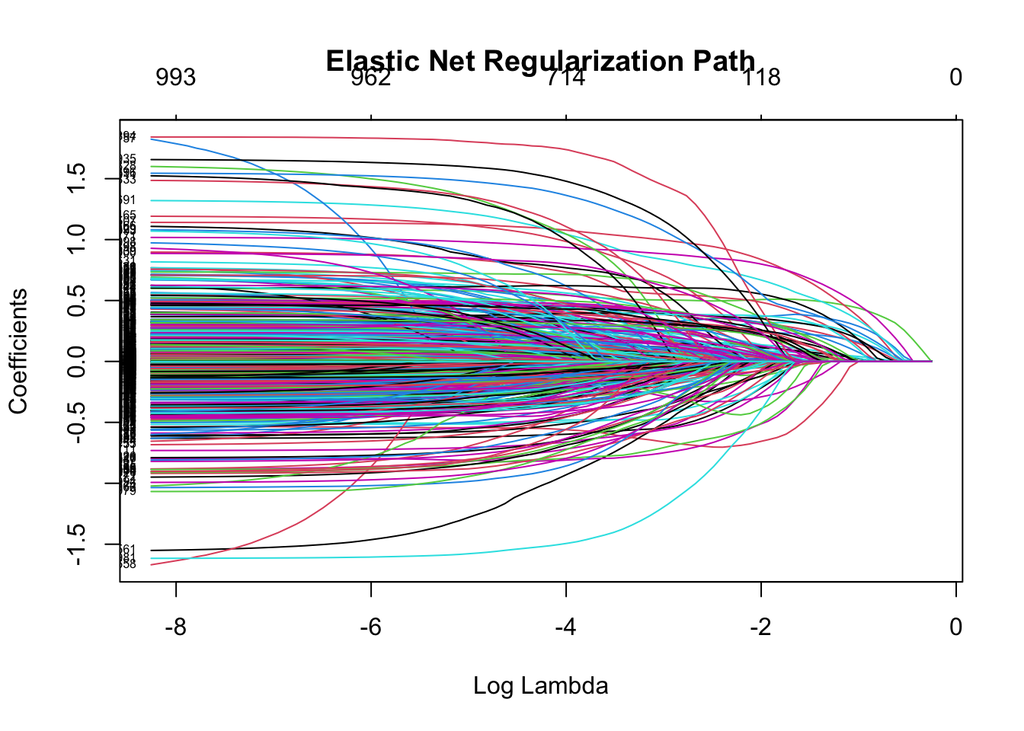

```r
## Using glmnet library (ChatGPT recommendation to adjust elastic net, similar commands)

# Elastic Net
set.seed(123)
alpha_value <- 0.3  # Elastic Net: Lasso combination (1) and Ridge (0)

spender_elastic <- glmnet(xweb, log(yspend), alpha = alpha_value, family = "gaussian")

plot(spender_elastic, xvar = "lambda", label = TRUE)
title("Elastic Net Regularization Path")
```

Intuition: Elastic Net selects more variables than Lasso in datasets with high multicollinearity, distributing weights across correlated predictors. In contrast, Lasso is more aggressive in eliminating irrelevant variables by shrinking their coefficients to zero.

## Experiment: Ridge (alpha = 0)

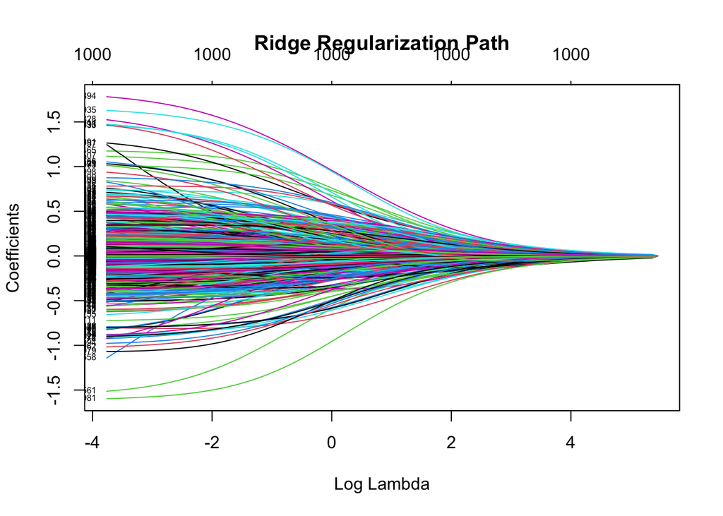

```r
ridge_model <- glmnet(
  xweb,
  log(yspend),
  alpha = 0,  # Ridge
  family = "gaussian"
)

plot(ridge_model, xvar = "lambda", label = TRUE)
title("Ridge Regularization Path")
```

Intuition: Ridge is more suitable when all variables contribute some information and multicollinearity is high. Lasso is better when you believe only a few variables are truly relevant.

### Main intuitions when comparing Lasso, Ridge and Elastic Net for this setup

- Lasso: For strict variable selection.
- Ridge: To stabilize coefficients when multicollinearity is present. ç
- Elastic Net: A balance between Lasso and Ridge, useful in cases of multicollinearity and dispersion.

### Sample of 10 coefficients: comparison

```r
# Seleccionar un subconjunto de coeficientes (por ejemplo, los primeros 10)
num_coeff <- 10  # Número de coeficientes a comparar

# Obtener los coeficientes de los primeros valores de cada modelo
coef_lasso <- as.matrix(coef(spender))[1:num_coeff, , drop = FALSE]  # Lasso
coef_elastic <- as.matrix(coef(spender_elastic))[1:num_coeff, , drop = FALSE]  # Elastic Net
coef_ridge <- as.matrix(coef(ridge_model))[1:num_coeff, , drop = FALSE]  # Ridge

# Crear una tabla comparativa con los primeros coeficientes
comparison_table <- data.frame(
  Coefficients = rownames(coef_lasso),
  `Lasso Coef` = coef_lasso[, 1],
  `Elastic Net Coef` = coef_elastic[, 1],
  `Ridge Coef` = coef_ridge[, 1]
)

# Imprimir la tabla con los primeros coeficientes
print(comparison_table)
```

```
##                                        Coefficients   Lasso.Coef
## intercept                                 intercept  5.880040755
## atdmt.com                                 atdmt.com  0.000000000
## yahoo.com                                 yahoo.com -0.003188405
## whenu.com                                 whenu.com  0.000000000
## weatherbug.com                       weatherbug.com  0.003583690
## msn.com                                     msn.com  0.000000000
## google.com                               google.com  0.000000000
## aol.com                                     aol.com -0.002620178
## questionmarket.com               questionmarket.com  0.030182620
## googlesyndication.com-o02 googlesyndication.com-o02 -0.009071994
##                           Elastic.Net.Coef    Ridge.Coef
## intercept                         6.190619  6.190619e+00
## atdmt.com                         0.000000  9.903305e-39
## yahoo.com                         0.000000 -3.647864e-39
## whenu.com                         0.000000 -7.331204e-39
## weatherbug.com                    0.000000  2.649360e-39
## msn.com                           0.000000  1.013754e-38
## google.com                        0.000000  9.149721e-39
## aol.com                           0.000000 -8.193426e-39
## questionmarket.com                0.000000  8.004475e-38
## googlesyndication.com-o02         0.000000 -1.738047e-38
```

Coefficients in Ridge seem to be insignificant. Elastic net drops more coefficients than Lasso in this sample of 10.

## KFold CV for Lasso

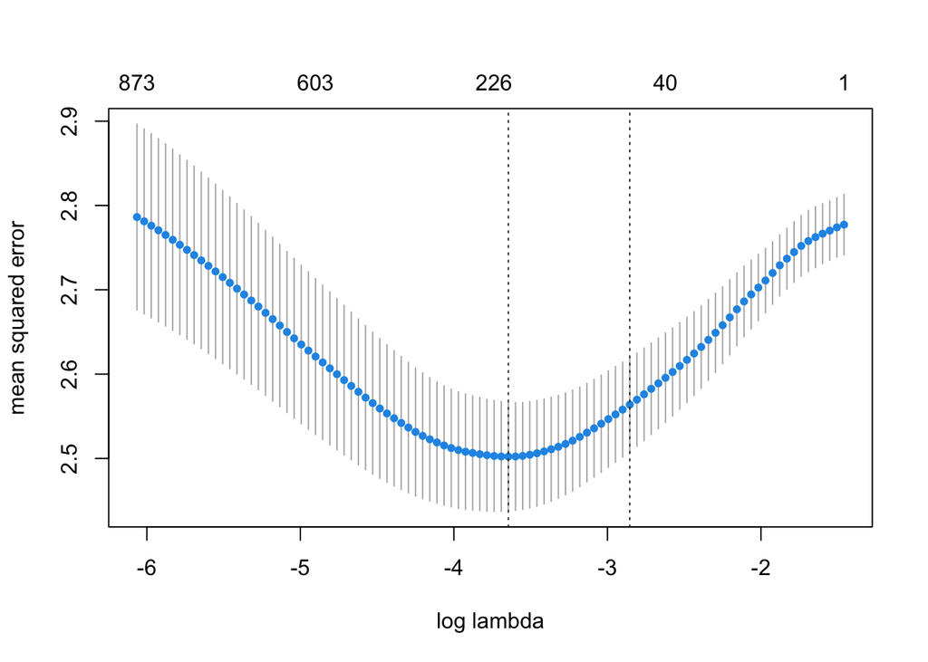

```r
cv.spender <- cv.gamlr(xweb, log(yspend))
plot(cv.spender)
```

```r
betamin = coef(cv.spender, select="min"); betamin
```

```
## 1001 x 1 sparse Matrix of class "dgCMatrix"
##                                        seg48
## intercept                       5.8793335364
## atdmt.com                       .
## yahoo.com                      -0.0025284207
## whenu.com                       .
## weatherbug.com                  0.0032617574
## msn.com                         .
## google.com                      .
## aol.com                        -0.0011920730
## questionmarket.com              0.0288274693
## googlesyndication.com-o02      -0.0077484251
## casalemedia.com                 .
## mywebsearch.com                 0.0016599255
## myspace.com                     .
## pointroll.com                   .
## atwola.com                      .
## yieldmanager.com                .
## live.com                        0.0026481568
## aim.com                         .
## mediaplex.com                   .
## precisionclick.com              .
## tribalfusion.com                .
## insightexpressai.com            .
## trafficmp.com                   .
## ebay.com                        .
## realmedia.com                   .
## zedo.com                        .
## advertising.com                -0.0004554512
## microsoft.com                   .
## hotbar.com                      .
## adrevolver.com                  .
## ru4.com                         0.0104306691
## 180solutions.com                .
## nextag.com                      .
## accuweather.com                 .
## overture.com                    .
## hotmail.com                     .
## passport.com                    .
## my-etrust.com                   0.0043605905
```

[output cut: 948 more lines]

```
## falkag.de                       0.0469884885
## chicagotribune.com              .
## airtran.com                     0.1433916128
## thebreastcancersite.com         .
## charmingshoppes.com             .
## ugo.com                         .
## cox.com                        -0.0013932075
## spicymint.com                   .
## real.com-o01                   -0.1313743387
## targetnet.com                   .
## effectivebrand.com              .
## dallascowboys.com               .
## leadgenetwork.com               .
## in.us                           .
## vistaprint.com                  0.4538462402
```

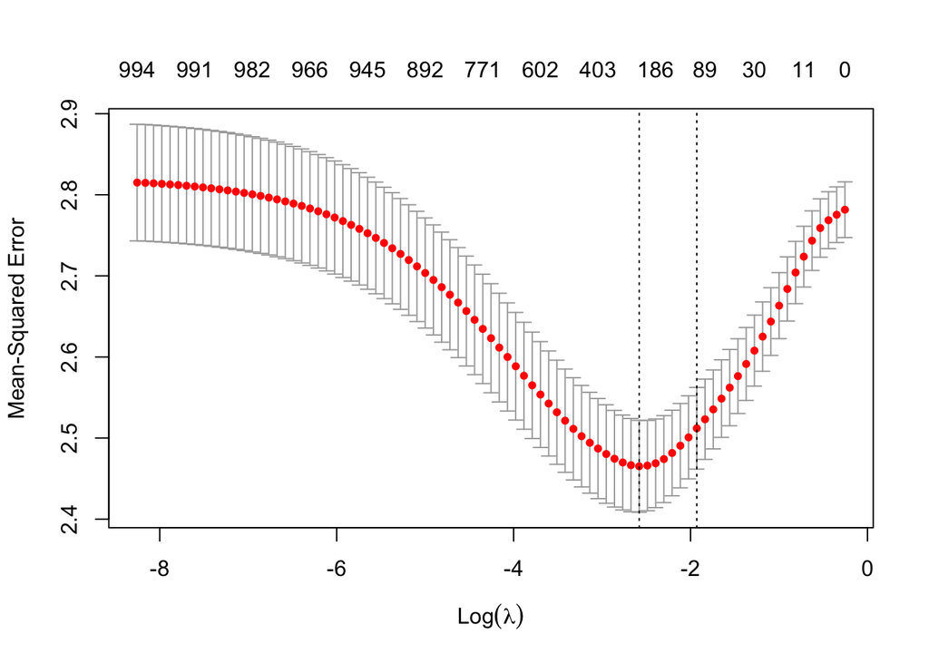

```r
cv_spender_elastic <- cv.glmnet(
  xweb,
  log(yspend),
  alpha = alpha_value,  #Elastic Net, alpha = 0.3
  family = "gaussian",
  nfolds = 10,  # 10-fold cross-validation
  type.measure = "mse"  # Min MSE
)

plot(cv_spender_elastic)
```

## Aikaike’s Info Criterion

```r
head(AIC(spender))
```

```
##     seg1     seg2     seg3     seg4     seg5     seg6
## 10236.68 10221.41 10205.65 10191.27 10178.15 10159.76
```

For AIC, the lower, the better.